# STAT 428: Project1

Du, Yuting, yutingd3

## Method - Sums and Mixtures

Generate chisquare random sample. If Z1, · · · , Zν are iid N(0,1) r.v., then
$$V = Z_1^2 + Z_2^2 + ....+Z_v^2$$
has the $χ^2(v)$ distribution.

1. Fill an n × ν matrix with ν r.v. from N(0,1).
2. Compute the row sums of the squared normals.
3. Deliver the vector of row sums.

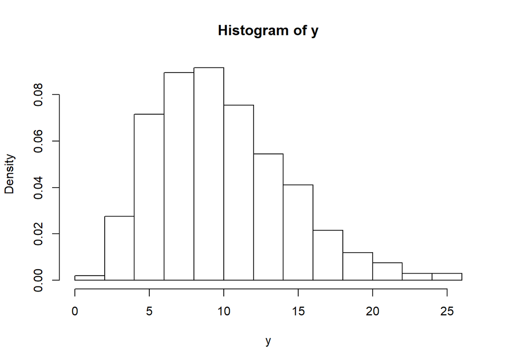

```r
n <- 1000
nu <- 10
X <- matrix(rnorm(n * nu), n, nu)^2 #matrix of sq. normals
# sum the squared normals across each row: method 1
y <- rowSums(X)


hist(y, probability = TRUE)
```

(Poisson-Gamma mixture) If$(X|\gamma = \lambda)$ follows $Poisson(\lambda)$ and $\gamma$ follows $Gamma(r, \beta)$ then X has the negative binomial dist. with parameters r and p = $\beta/(1+\beta)$

```r
# generate a Poisson-Gamma mixture

n <- 1000
r <- 4
beta <- 3
lambda <- rgamma(n, r, beta) #lambda is random
# now supply the sample of lambda's as the Poisson mean
x <- rpois(n, lambda) #the mixture
# compare with negative binomial
mix <- tabulate(x + 1)/n
negbin <- round(dnbinom(0:max(x), r, beta/(1 + beta)), 3)
se <- sqrt(negbin * (1 - negbin)/n)
round(rbind(mix, negbin, se), 3)
```

```
##         [,1]  [,2]  [,3]  [,4]  [,5]  [,6]  [,7]  [,8]  [,9]
## mix    0.341 0.311 0.190 0.103 0.031 0.018 0.003 0.002 0.001
## negbin 0.316 0.316 0.198 0.099 0.043 0.017 0.006 0.002 0.001
## se     0.015 0.015 0.013 0.009 0.006 0.004 0.002 0.001 0.001
```

Mixture of several gamma distribution

1. Generating a random sample k1,….,$k_n$ of intergers in vector k, where $P(k) = \theta_k$, k = 1,….5. $k[i]$ indicates which of the five gamma distribution will be sampled to get the ith element of sample
2. Set rate equal to the length n vector $\lambda = \lambda_k$
3. Generate a gamma sample size n, with shape parameter $r$ and rate vector rate (for comparison)

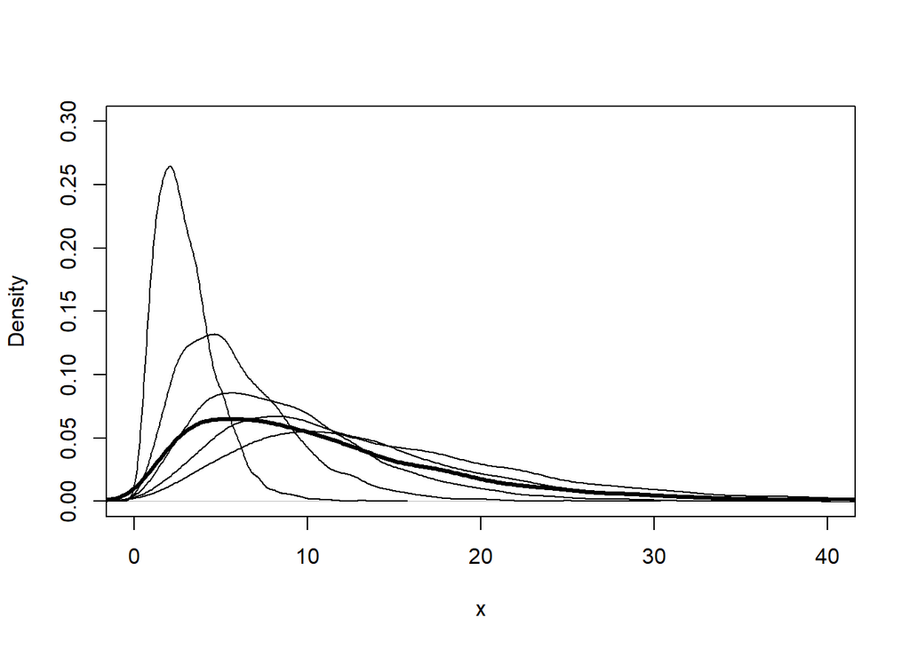

```r
n <- 5000
k <- sample (1:5 , size =n , replace = TRUE , prob =(1:5) /15)
rate <- 1/k ; x <- rgamma (n , shape =3 , rate = rate )

# plot the density of the mixture with the densities of the components
plot ( density ( x ) , xlim =c(0 ,40) , ylim =c(0 ,.3) ,
lwd =3 , xlab ="x", main ="")
for ( i in 1:5){
  lines ( density ( rgamma (n , 3 , 1/i )))
}
```

## Method2 Marsaglia and Tsang’s Method

[reference](https://www.hongliangjie.com/2012/12/19/how-to-generate-gamma-random-variables/)

The algorithm works as follows for $\mathbf{X} \sim \mbox{Gamma}(\alpha, 1)$ for $\alpha \geq 1$

1. Set $d = \alpha - 1/3$ and $c = 1/\sqrt{9d}$.
2. Generate $Z \sim \mbox{N}(0,1)$ and $U \sim \mbox{U}(0,1)$ independently.
3. If $Z > -1/c$ and $\log U < \frac{1}{2} Z^{2} + d - d V + d \times ln V$, where $V = (1+cZ)^{3}$, return $\mathbf{X} = d \times V$; otherwise, go back to Step 2.

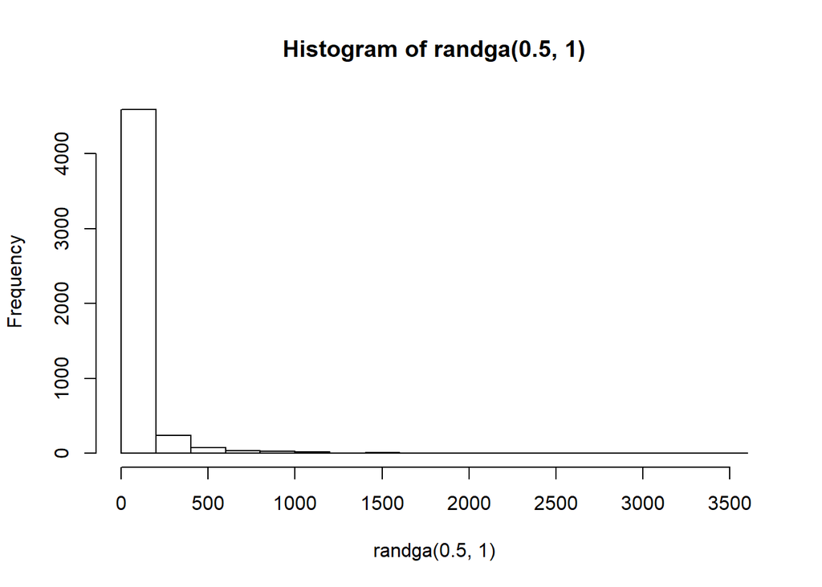

```r
randga = function(a, b){
  if(a>1){
    d = a -1/3
    c = 1/sqrt(9*d)
    flag = TRUE
    while(flag){
      z = rnorm(1000)
      if (z > -1/c){
        v = (1+c*x)^3
        u = runif(1000)
        flag = log(u) > (0.5*z^2+d-d*v+d*log(v))
      }
    }
    x = d*v/b
  } else {
    x = randga(a+1, b)
    x = x* runif(1000)^(1/a)
  }
  return (x)
}

hist(randga(0.5, 1))
```

## Method3 Ahrens-Dieter Table-Free Normal General

[reference](https://www.doc.ic.ac.uk/~wl/papers/07/csur07dt.pdf)

The Ahrens-Dieter Table-Free method is an exact Gaussian generator that transforms a pair of independent exponential and Cauchy random numbers into two independent Gaussian random numbers [Ahrens and Dieter 1988]. This is similar to the idea behind the Box-Muller method, except that instead of applying a complex transform to easily generated uniform random numbers, it applies a simpler transform to two distributions that are more complex to generate. In principle, the exponential and Cauchy distributions could be generated directly, using − ln U and tan(π(U − 1/2)) respectively, which would make this a transform method.

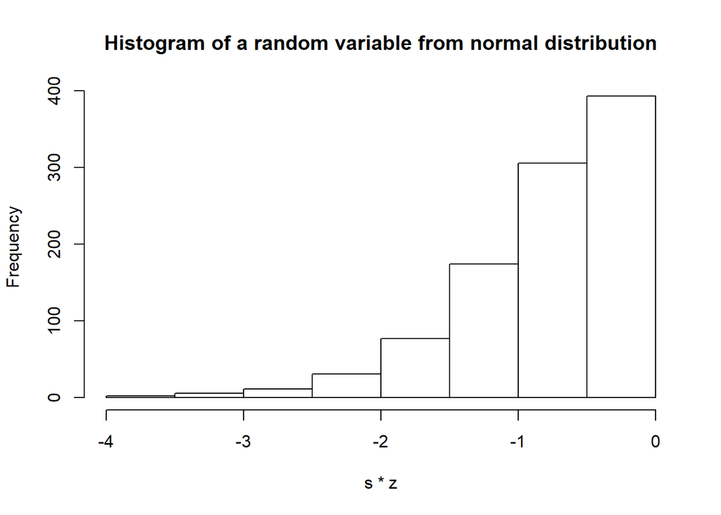

```r
s = runif(1000)
if(s < 0.5){
  s = 1
} else {
  s = -1
}
x = rexp(1000)
y = rcauchy(1000)

z = sqrt((2*x)/(1+y^2))

hist(s*z, main = "Histogram of a random variable from normal distribution")
```

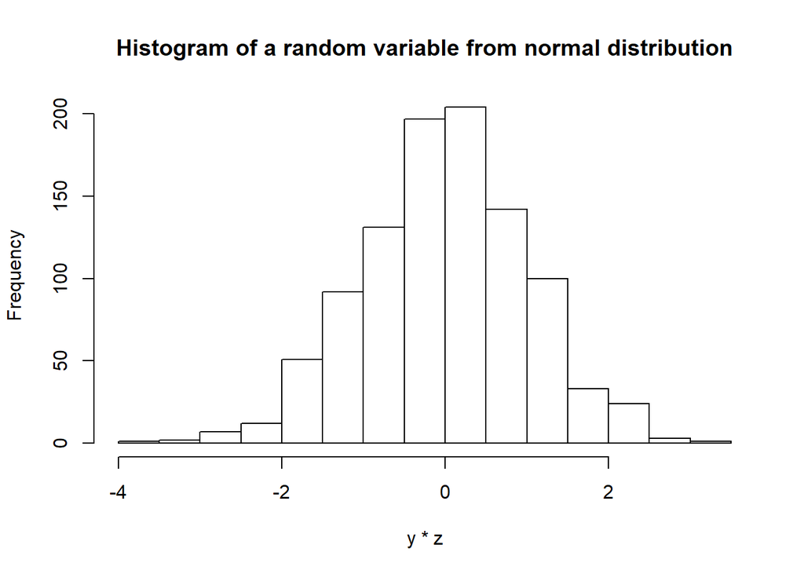

```r
hist(y*z, main = "Histogram of a random variable from normal distribution")
```

## Peer Review

Team members:Yue Wang(yue18), Jiangong Li(jli153), Yifan Sun(yifans8), Mengyuan Zhang(mz37)

Jli153: If possible, you can write some equations to help others to understand the methods.In method 3, the use of U ( ==s in the code?) should be further expanded or just ignore it at all.

Mz37: Is it better to write an abstract part at the beginning since you have so many topics to introduce?

Yifan (yifans8): I am so impressed that you used three methods and put at least one example in each method in your report. I am more familiar with the first method than the other two, so maybe you could explain the algorithm of the second and third methods more detailed.

Yue18: Very good! You must put a lot of effort into the project since there are three methods in your report.

## feedback to review

I have added the implementation about s in the third method. Thanks for suggestion!

Sure. I have added some algorithm explaination for method 2. Thanks!

Thanks!